# Assignment 3

Due at 11:59pm on October 24.

Author

Leng Seong Che; Bozhou(Peter) Tan

You may work in pairs or individually for this assignment. Make sure you join a group in Canvas if you are working in pairs. Turn in this assignment as an HTML or PDF file to ELMS. Make sure to include the R Markdown or Quarto file that was used to generate it. Include the GitHub link for the repository containing these files.

Github: https://github.com/petertbz/Assignment-3--727.git

```r
library(xml2)
library(rvest)
library(tidyverse)
library(robotstxt)
library(dplyr)
library(knitr)
```

## Web Scraping

In this assignment, your task is to scrape some information from Wikipedia. We start with the following page about Grand Boulevard, a Chicago Community Area.

https://en.wikipedia.org/wiki/Grand_Boulevard,_Chicago

The ultimate goal is to gather the table “Historical population” and convert it to a `data.frame`.

As a first step, read in the html page as an R object. Extract the tables from this object (using the `rvest` package) and save the result as a new object. Follow the instructions if there is an error. Use `str()` on this new object -- it should be a list. Try to find the position of the “Historical population” in this list since we need it in the next step.

```r
# determine the paths and url
paths_allowed("https://en.wikipedia.org/wiki/Grand_Boulevard,_Chicago")
```

```
[1] TRUE
```

```r
url = read_html("https://en.wikipedia.org/wiki/Grand_Boulevard,_Chicago")

# extract tables from the website
nds = html_elements(url, xpath = '//table')
str(nds)
```

```
List of 7
 $ :List of 2
  ..$ node:<externalptr>
  ..$ doc :<externalptr>
  ..- attr(*, "class")= chr "xml_node"
 $ :List of 2
  ..$ node:<externalptr>
  ..$ doc :<externalptr>
  ..- attr(*, "class")= chr "xml_node"
 $ :List of 2
  ..$ node:<externalptr>
  ..$ doc :<externalptr>
  ..- attr(*, "class")= chr "xml_node"
 $ :List of 2
  ..$ node:<externalptr>
  ..$ doc :<externalptr>
  ..- attr(*, "class")= chr "xml_node"
 $ :List of 2
  ..$ node:<externalptr>
  ..$ doc :<externalptr>
  ..- attr(*, "class")= chr "xml_node"
 $ :List of 2
  ..$ node:<externalptr>
  ..$ doc :<externalptr>
  ..- attr(*, "class")= chr "xml_node"
 $ :List of 2
  ..$ node:<externalptr>
  ..$ doc :<externalptr>
  ..- attr(*, "class")= chr "xml_node"
 - attr(*, "class")= chr "xml_nodeset"
```

Extract the “Historical population” table from the list and save it as another object. You can use subsetting via `[[…]]` to extract pieces from a list. Print the result.

```r
# extract "Historical population" table from the list
hp = nds[[2]]
hpset = html_table(hp)
kable(hpset, caption = "Historical population")
```

Historical population

| Census | Pop. | .mw-parser-output .sr-only{border:0;clip:rect(0,0,0,0);clip-path:polygon(0px 0px,0px 0px,0px 0px);height:1px;margin:-1px;overflow:hidden;padding:0;position:absolute;width:1px;white-space:nowrap}Note | %± |
| --- | --- | --- | --- |
| 1930 | 87,005 |  | — |
| 1940 | 103,256 |  | 18.7% |
| 1950 | 114,557 |  | 10.9% |
| 1960 | 80,036 |  | −30.1% |
| 1970 | 80,166 |  | 0.2% |
| 1980 | 53,741 |  | −33.0% |
| 1990 | 35,897 |  | −33.2% |
| 2000 | 28,006 |  | −22.0% |
| 2010 | 21,929 |  | −21.7% |
| 2020 | 24,589 |  | 12.1% |
| [3][1] | [3][1] | [3][1] | [3][1] |

You will see that the table needs some additional formatting. We only want rows and columns with actual values (I called the table object `pop`).

```r
# remove unwanted rows and columns
pop = hpset[2:10, -3]
kable(pop, caption = "Historical population")
```

Historical population

| Census | Pop. | %± |
| --- | --- | --- |
| 1940 | 103,256 | 18.7% |
| 1950 | 114,557 | 10.9% |
| 1960 | 80,036 | −30.1% |
| 1970 | 80,166 | 0.2% |
| 1980 | 53,741 | −33.0% |
| 1990 | 35,897 | −33.2% |
| 2000 | 28,006 | −22.0% |
| 2010 | 21,929 | −21.7% |
| 2020 | 24,589 | 12.1% |

## Expanding to More Pages

That’s it for this page. However, we may want to repeat this process for other community areas. The Wikipedia page https://en.wikipedia.org/wiki/Grand_Boulevard,_Chicago has a section on “Places adjacent to Grand Boulevard, Chicago” at the bottom. Can you find the corresponding table in the list of tables that you created earlier? Extract this table as a new object.

```r
# extract the table
adj = html_table(nds[[3]])
```

Then, grab the community areas east of Grand Boulevard and save them as a character vector. Print the result.

```r
adjeast = as.vector(adj[c(2,4,6), 3])
print(adjeast)
```

```
[[1]]
[1] "Oakland, Chicago"   "Kenwood, Chicago"   "Hyde Park, Chicago"
```

We want to use this list to create a loop that extracts the population tables from the Wikipedia pages of these places. To make this work and build valid urls, we need to replace empty spaces in the character vector with underscores. This can be done with `gsub()`, or by hand. The resulting vector should look like this: “Oakland,_Chicago” “Kenwood,_Chicago” “Hyde_Park,_Chicago”

```r
places_east = gsub(' ', '_', adjeast[[1]])
places_east
```

```
[1] "Oakland,_Chicago"   "Kenwood,_Chicago"   "Hyde_Park,_Chicago"
```

To prepare the loop, we also want to copy our `pop` table and rename it as `pops`. In the loop, we append this table by adding columns from the other community areas.

```r
pops = pop
```

Build a small loop to test whether you can build valid urls using the vector of places and pasting each element of it after `https://en.wikipedia.org/wiki/` in a for loop. Calling `url` shows the last url of this loop, which should be `https://en.wikipedia.org/wiki/Hyde_Park,_Chicago`.

```r
for(i in 1:length(places_east)) {
  url <- paste("https://en.wikipedia.org/wiki/", places_east[i], sep = "")
}
url
```

```
[1] "https://en.wikipedia.org/wiki/Hyde_Park,_Chicago"
```

Finally, extend the loop and add the code that is needed to grab the population tables from each page. Add columns to the original table `pops` using `cbind()`.

```r
for(i in 1:length(places_east)) {
  url = read_html(paste("https://en.wikipedia.org/wiki/", places_east[i], sep = ""))
  nds = html_elements(url, xpath = '//table')
  hp = nds[[2]]
  hpset = html_table(hp)
  pops = hpset[2:10, -3] %>% cbind(pops, .)
}

kable(pops, caption = "Historical population")
```

Historical population

| Census | Pop. | %± | Census | Pop. | %± | Census | Pop. | %± | Census | Pop. | %± |
| --- | --- | --- | --- | --- | --- | --- | --- | --- | --- | --- | --- |
| 1940 | 103,256 | 18.7% | 1940 | 14,500 | −3.1% | 1940 | 29,611 | 9.9% | 1940 | 50,550 | 5.3% |
| 1950 | 114,557 | 10.9% | 1950 | 24,464 | 68.7% | 1950 | 35,705 | 20.6% | 1950 | 55,206 | 9.2% |
| 1960 | 80,036 | −30.1% | 1960 | 24,378 | −0.4% | 1960 | 41,533 | 16.3% | 1960 | 45,577 | −17.4% |
| 1970 | 80,166 | 0.2% | 1970 | 18,291 | −25.0% | 1970 | 26,890 | −35.3% | 1970 | 33,531 | −26.4% |
| 1980 | 53,741 | −33.0% | 1980 | 16,748 | −8.4% | 1980 | 21,974 | −18.3% | 1980 | 31,198 | −7.0% |
| 1990 | 35,897 | −33.2% | 1990 | 8,197 | −51.1% | 1990 | 18,178 | −17.3% | 1990 | 28,630 | −8.2% |
| 2000 | 28,006 | −22.0% | 2000 | 6,110 | −25.5% | 2000 | 18,363 | 1.0% | 2000 | 29,920 | 4.5% |
| 2010 | 21,929 | −21.7% | 2010 | 5,918 | −3.1% | 2010 | 17,841 | −2.8% | 2010 | 25,681 | −14.2% |
| 2020 | 24,589 | 12.1% | 2020 | 6,799 | 14.9% | 2020 | 19,116 | 7.1% | 2020 | 29,456 | 14.7% |

## Scraping and Analyzing Text Data

Suppose we wanted to take the actual text from the Wikipedia pages instead of just the information in the table. Our goal in this section is to extract the text from the body of the pages, then do some basic text cleaning and analysis.

First, scrape just the text without any of the information in the margins or headers. For example, for “Grand Boulevard”, the text should start with, “**Grand Boulevard** on the [South Side](https://en.wikipedia.org/wiki/South_Side,_Chicago) of Chicago, Illinois, is one of the …”. Make sure all of the text is in one block by using something like the code below (I called my object `description`).

```r
url = read_html("https://en.wikipedia.org/wiki/Grand_Boulevard,_Chicago")
nds = html_nodes(url, xpath = "//p")
description = html_text2(nds)[-1]

description = description %>%
    paste(collapse = " ")

kable(data.frame(description = description), caption = "description")
```

description

description

Grand Boulevard on the South Side of Chicago, Illinois, is one of the city’s Community Areas. The boulevard from which it takes its name is now Martin Luther King Jr. Drive. The area is bounded by 39th to the north, 51st Street to the south, Cottage Grove Avenue to the east, and the Chicago, Rock Island & Pacific Railroad tracks to the west. This is one of the two community areas that encompass the Bronzeville neighborhood, with the other being Douglas. Grand Boulevard also includes the Washington Park Court District neighborhood that was declared a Chicago Landmark on October 2, 1991.[2] The Harold Washington Cultural Center is one of its newer and more famous buildings. It arose on the site that from the 1920s through the 1970s housed a famous center of African American cultural life, the Regal Theater. Among the other notable properties in this neighborhood are the Daniel Hale Williams House, the Robert S. Abbott House, and the Oscar Stanton De Priest House. According to a 2018 US Census American Community Survey, there were 22,784 people and 10,383 households in Grand Boulevard.[1] The racial makeup of the area was 92.56% African American, 2.70% White, 0.70% Asian, and 2.26% from other races. Hispanic or Latino residents of any race were 1.77% of the population.[1] In the area, the population was spread out, with 27.3% under the age of 19, 19.4% from 20 to 34, 22.6% from 35 to 49, 16.4% from 50 to 64, and 14.3% who were 65 years of age or older. The median age was 36.9 years.[1] Grand Boulevard is part of City of Chicago School District #299 and City Colleges of Chicago District #508. The nearest City Colleges campus was Kennedy–King College in Englewood. A high school diploma had been earned by 85.5% of Grand Boulevard residents and a bachelor’s degree or greater had been earned by 31.31% of residents compared to citywide figures of 82.3% and 35.6% respectively.[1] The Chicago Transit Authority operates the Chicago “L” system in the Grand Boulevard community area. The Green Line provides rapid transit at four stations: Indiana, 43rd Street, 47th Street and 51st Street stations. The Grand Boulevard community area has supported the Democratic Party in the past two presidential elections by overwhelming margins. In the 2016 presidential election, Grand Boulevard cast 10,081 votes for Hillary Clinton and cast 171 votes for Donald Trump.[4] In the 2012 presidential election, Grand Boulevard cast 10,646 votes for Barack Obama and cast 81 votes for Mitt Romney.[5]

Using a similar loop as in the last section, grab the descriptions of the various communities areas. Make a tibble with two columns: the name of the location and the text describing the location.

```r
descriptions = data.frame(location = "Grand_Boulevard", description = description)

places_east2 = gsub(",_Chicago", "", places_east) %>%
  as_tibble() %>%
  rename(location = value)

for(i in 1:length(places_east)) {
  url = read_html(paste("https://en.wikipedia.org/wiki/", places_east[i], sep = ""))
  nds = html_elements(url, xpath = '//p')
  description = html_text2(nds)[-1] %>%
    paste(collapse = ' ')
  descriptionss = data.frame(location = places_east2[i,1], description = description)

descriptions = rbind(descriptions, descriptionss)
}

kable(descriptions, caption = "descriptions")
```

descriptions

| location | description |
| --- | --- |
| Grand_Boulevard | Grand Boulevard on the South Side of Chicago, Illinois, is one of the city’s Community Areas. The boulevard from which it takes its name is now Martin Luther King Jr. Drive. The area is bounded by 39t… |
| Oakland | The Oakland neighborhood originally formed out of a settlement named “Cleaverville”. In 1851, Charles Cleaver, an industrialist, purchased 22 acres near 38th Street and Lake Michigan. Real-estate deve… |
| Kenwood | Kenwood, one of Chicago’s 77 community areas, is on the shore of Lake Michigan on the South Side of the city. Its boundaries are 43rd Street, 51st Street, Cottage Grove Avenue, and the lake. Kenwood w… |
| Hyde_Park | Hyde Park is the 41st of the 77 community areas of Chicago. It is located on the South Side, near the shore of Lake Michigan 7 miles (11 km) south of the Loop. Hyde Park’s official boundaries are 51st… |

Let’s clean the data using `tidytext`. If you have trouble with this section, see the example shown in https://www.tidytextmining.com/tidytext.html

```r
library(tidytext)
```

Create tokens using `unnest_tokens`. Make sure the data is in one-token-per-row format. Remove any stop words within the data. What are the most common words used overall?

```r
# construct tokens
tidyt = descriptions %>% unnest_tokens(word, description)

# remove any stop words
data("stop_words")
tidyt = tidyt %>%
  anti_join(stop_words)

tidymost = tidyt %>% count(word, sort = TRUE)
kable(head(tidymost), caption = "Most Common Words")
```

Most Common Words

| word | n |
| --- | --- |
| park | 88 |
| hyde | 75 |
| chicago | 54 |
| street | 43 |
| kenwood | 38 |
| community | 26 |

From the table above, we can see that “park” is the most common word, followed by “hyde”, “chicago”, “street” and “kenwood”.

Plot the most common words within each location. What are some of the similarities between the locations? What are some of the differences?

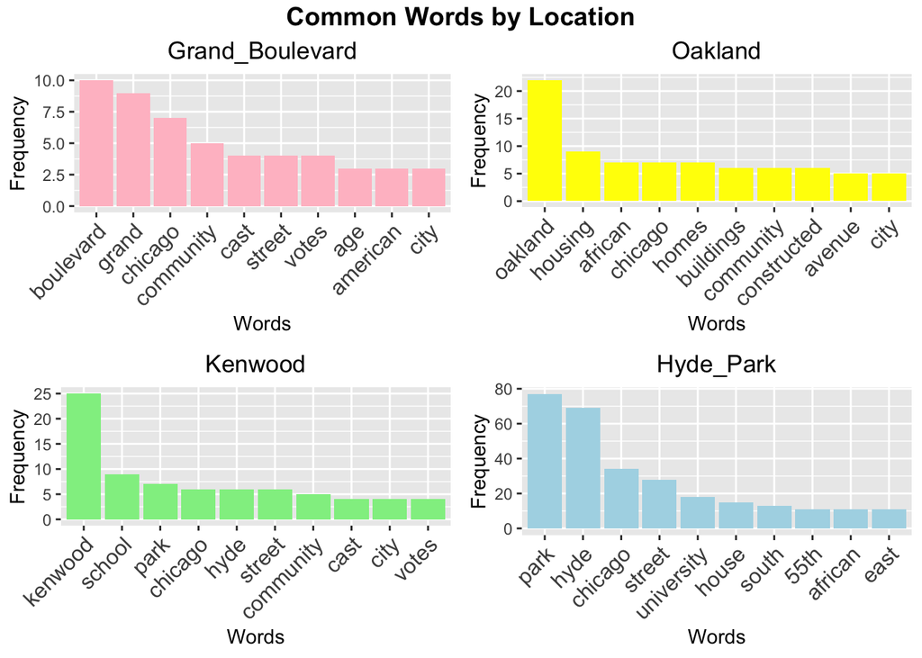

```r
library(forcats)
library(ggpubr)

Grand_Boulevard = tidyt %>%
  filter(location == "Grand_Boulevard") %>%
  count(word, sort = TRUE) %>%
  filter(word != "1" & word != "2") %>%
  head(10)

Oakland = tidyt %>%
  filter(location == "Oakland") %>%
  count(word, sort = TRUE) %>%
  filter(word != "1" & word != "2") %>%
  head(10)

Kenwood = tidyt %>%
  filter(location == "Kenwood") %>%
  count(word, sort = TRUE) %>%
  filter(word != "1" & word != "2") %>%
  head(10)

Hyde_Park = tidyt %>%
  filter(location == "Hyde_Park") %>%
  count(word, sort = TRUE) %>%
  filter(word != "1" & word != "2") %>%
  head(10)

p1 = ggplot(Grand_Boulevard, aes(x = fct_infreq(word, n), y = n)) +
  geom_bar(stat = "identity", fill = "pink") +
  ggtitle("Grand_Boulevard") +
  theme(plot.title = element_text(hjust = 0.5),
        axis.text.x = element_text(angle = 45, hjust = 1,size = 12)) +
  labs(y = "Frequency",
       x = "Words")

p2 = ggplot(Oakland, aes(x = fct_infreq(word, n), y = n)) +
  geom_bar(stat = "identity", fill = "yellow") +
  ggtitle("Oakland") +
  theme(plot.title = element_text(hjust = 0.5),
        axis.text.x = element_text(angle = 45, hjust = 1,size = 12)) +
  labs(y = "Frequency",
       x = "Words")

p3 = ggplot(Kenwood, aes(x = fct_infreq(word, n), y = n)) +
  geom_bar(stat = "identity", fill = "lightgreen") +
  ggtitle("Kenwood") +
  theme(plot.title = element_text(hjust = 0.5),
        axis.text.x = element_text(angle = 45, hjust = 1,size = 12)) +
  labs(y = "Frequency",
       x = "Words")

p4 = ggplot(Hyde_Park, aes(x = fct_infreq(word, n), y = n)) +
  geom_bar(stat = "identity", fill = "lightblue") +
  ggtitle("Hyde_Park") +
  theme(plot.title = element_text(hjust = 0.5),
        axis.text.x = element_text(angle = 45, hjust = 1,size = 12)) +
  labs(y = "Frequency",
       x = "Words")

plot = ggarrange(p1, p2, p3, p4, ncol = 2, nrow = 2)
annotate_figure(plot, top = text_grob("Common Words by Location",
              face = "bold", size = 14))
```

From the plot above, we can see that the three most common words of Grand_Boulevard is “boulevard”, “grand” and “chicago”. For Oakland, they are “oakland”, “housing” and “african”; For Kenwood, they are “kenwood”, “school” and “park”; For Hyde_Park, they are “park”, “hyde” and “chicago”. We can see that they are mainly the name of the location or the nearby big city Chicago. All communities except for Oakland have “street” as one of the ten most common words. Kenwood and Hyde Park mention a large number of words “school” and “university,” respectively, while the other two do not mention educational institutes as much. This difference is likely due to the former two communities have more schools or more prestigious ones that people think worth mentioning while introducing the places to the public.